# Lista de Exercícios - 1

Importe a planilha de dados exercicio1.xlsx. Organize os dados na forma de uma série temporal mensal com início no mês de maio de 1989.

```r
library(readxl)
dados <- read_excel("exercicio1.xlsx")
dados
```

| Zt |
| --- |
| 49.61 |
| 49.54 |
| 49.81 |
| 49.94 |
| 50.33 |
| 50.21 |
| 49.88 |
| 49.59 |
| 50.04 |
| 50.75 |

[output cut: 90 more lines]

```r
dados.serie <- ts(dados, start = c(1989,5), frequency=12)
dados.serie
```

```
##        Jan   Feb   Mar   Apr   May   Jun   Jul   Aug   Sep   Oct   Nov   Dec
## 1989                         49.61 49.54 49.81 49.94 50.33 50.21 49.88 49.59
## 1990 50.04 50.75 50.66 50.23 49.73 49.44 49.62 49.74 50.10 50.05 50.15 49.99
## 1991 50.15 50.59 50.43 50.03 50.13 50.36 49.79 49.90 50.24 50.22 49.73 49.25
## 1992 49.63 49.90 50.15 50.56 50.42 49.82 49.84 50.09 49.98 50.24 50.45 50.22
## 1993 49.97 50.27 50.61 49.88 49.84 50.26 49.82 49.86 49.75 50.27 50.59 49.83
## 1994 49.64 49.93 49.67 50.03 50.35 49.56 49.52 49.91 49.72 49.93 49.98 50.08
## 1995 50.30 50.27 49.76 49.74 49.67 49.67 49.87 49.96 49.65 49.48 49.79 49.33
## 1996 49.81 50.48 50.13 50.03 49.99 50.27 50.35 49.90 49.93 49.86 49.91 50.42
## 1997 50.33 50.17 50.12 50.02 50.22 50.08 50.15 50.36
```

1. Plote o gráfico da série temporal. Comente sobre as características perceptíveis no gráfico.

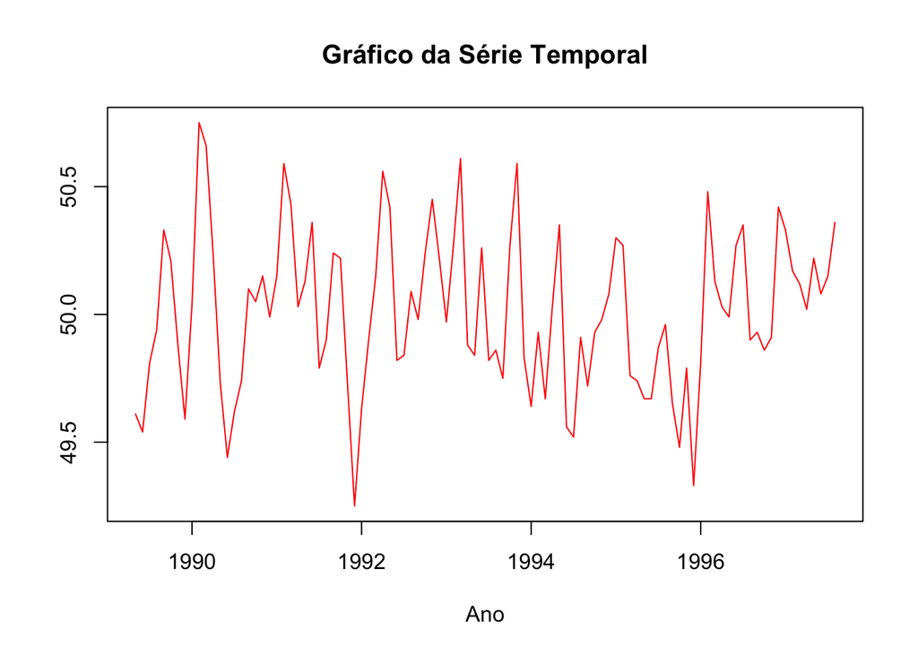

```r
plot(dados.serie, xlab="Ano", ylab="", col="red", main="Gráfico da Série Temporal")
```

2. Plote o periodograma integrado. Comente sobre as característica perceptíveis no gráfico.

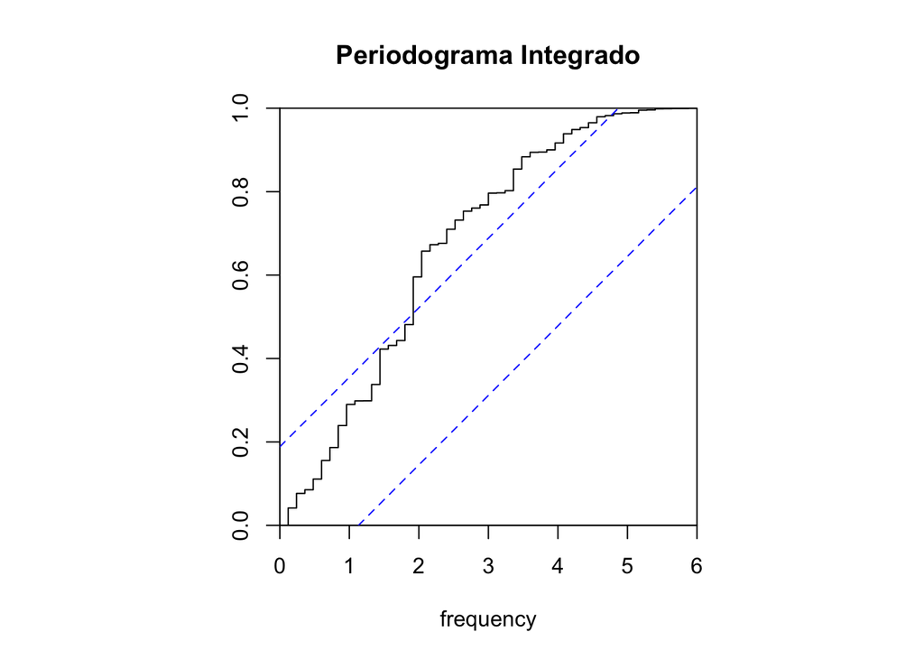

```r
cpgram(dados.serie, main="Periodograma Integrado")
```

3. Plote a decomposição da série temporal. Comente sobre as características perceptíveis no gráfico da tendência e sazonalidade.

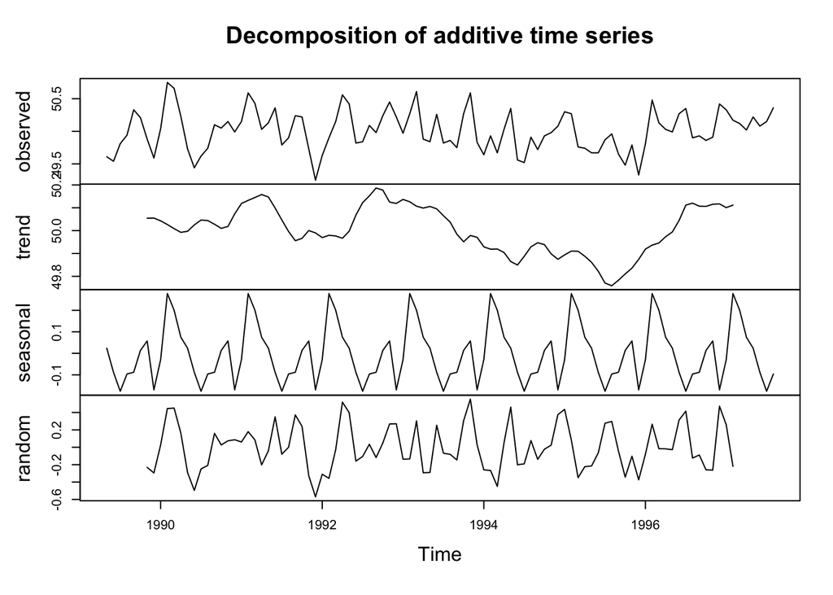

```r
dados.decomp <- decompose(dados.serie)
plot(dados.decomp)
```

4. Aplique o teste ADF. Interprete o resultado do teste.

```r
library(tseries)
adf.test(dados.serie)
```

```
##
##  Augmented Dickey-Fuller Test
##
## data:  dados.serie
## Dickey-Fuller = -3.5615, Lag order = 4, p-value = 0.04015
## alternative hypothesis: stationary
```

5. Obtenha um modelo ARIMA(p,d,q)

```r
library(forecast)

dados.serie.ARIMA <- auto.arima(dados.serie)
summary(dados.serie.ARIMA)
```

```
## Series: dados.serie
## ARIMA(0,0,1) with non-zero mean
##
## Coefficients:
##          ma1     mean
##       0.8401  50.0096
## s.e.  0.0561   0.0439
##
## sigma^2 = 0.05865:  log likelihood = 0.31
## AIC=5.37   AICc=5.62   BIC=13.19
##
## Training set error measures:
##                        ME      RMSE       MAE        MPE      MAPE      MASE
## Training set 0.0002330632 0.2397421 0.1967858 -0.0017668 0.3937264 0.5838554
##                     ACF1
## Training set -0.04071152
```

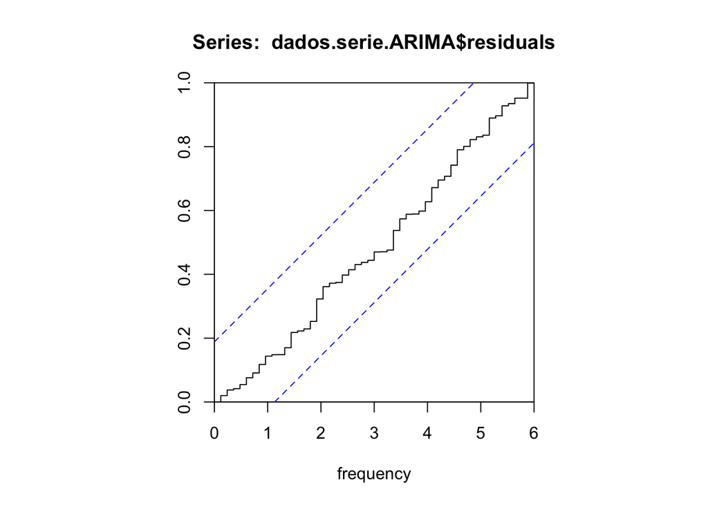

```r
cpgram(dados.serie.ARIMA$residuals)
```

1. Quantos parâmetros o modelo possui na porção autorregressiva?
2. Quantos parâmetros o modelo possui na porção de médias móveis?
3. O modelo ajustado considera a sazonalidade? Caso afirmativo, indique quantos parâmetros em cada porção sazonal.
4. Comente sobre as características perceptíveis no gráfico do periodograma integrado para os resíduos do modelo.
6. Ajuste um modelo de suavização exponencial de Holt-Winters

```r
HW.dados.serie <- hw(dados.serie)
summary(HW.dados.serie)
```

```
##
## Forecast method: Holt-Winters' additive method
##
## Model Information:
## Holt-Winters' additive method
##
## Call:
## hw(y = dados.serie)
##
##   Smoothing parameters:
##     alpha = 0.1284
##     beta  = 1e-04
##     gamma = 1e-04
##
##   Initial states:
##     l = 50.0049
##     b = 0.0023
##     s = 0.076 0.2267 0.2665 -0.0246 -0.2213 0.058
##            0.0038 -0.0299 -0.0568 -0.1253 -0.0949 -0.0782
##
##   sigma:  0.3099
##
##      AIC     AICc      BIC
## 242.7665 250.2299 287.0544
##
## Error measures:
##                        ME     RMSE       MAE         MPE      MAPE      MASE
## Training set -0.005382077 0.284008 0.2367794 -0.01374428 0.4734209 0.7025146
##                   ACF1
## Training set 0.3838811
##
## Forecasts:
##          Point Forecast    Lo 80    Hi 80    Lo 95    Hi 95
## Sep 1997       50.13288 49.73576 50.53001 49.52553 50.74023
## Oct 1997       50.16887 49.76848 50.56926 49.55652 50.78121
## Nov 1997       50.22537 49.82174 50.62901 49.60807 50.84268
## Dec 1997       49.94836 49.54150 50.35522 49.32612 50.57060
## Jan 1998       50.14725 49.73718 50.55731 49.52011 50.77439
## Feb 1998       50.44066 50.02741 50.85391 49.80865 51.07267
## Mar 1998       50.40312 49.98670 50.81953 49.76627 51.03997
## Apr 1998       50.25472 49.83516 50.67428 49.61306 50.89638
## May 1998       50.10290 49.68022 50.52559 49.45646 50.74935
## Jun 1998       50.08832 49.66252 50.51411 49.43712 50.73951
## Jul 1998       50.06022 49.63133 50.48911 49.40429 50.71614
## Aug 1998       50.13097 49.69901 50.56293 49.47035 50.79160
## Sep 1998       50.16017 49.72515 50.59520 49.49486 50.82549
## Oct 1998       50.19616 49.75810 50.63423 49.52620 50.86612
## Nov 1998       50.25267 49.81158 50.69376 49.57808 50.92726
## Dec 1998       49.97566 49.53156 50.41975 49.29647 50.65485
## Jan 1999       50.17454 49.72745 50.62163 49.49077 50.85831
## Feb 1999       50.46796 50.01789 50.91803 49.77964 51.15628
## Mar 1999       50.43041 49.97738 50.88344 49.73756 51.12326
## Apr 1999       50.28202 49.82604 50.73800 49.58465 50.97938
## May 1999       50.13020 49.67128 50.58911 49.42835 50.83205
## Jun 1999       50.11561 49.65378 50.57744 49.40930 50.82192
## Jul 1999       50.08751 49.62277 50.55225 49.37675 50.79827
## Aug 1999       50.15827 49.69063 50.62590 49.44308 50.87345
```

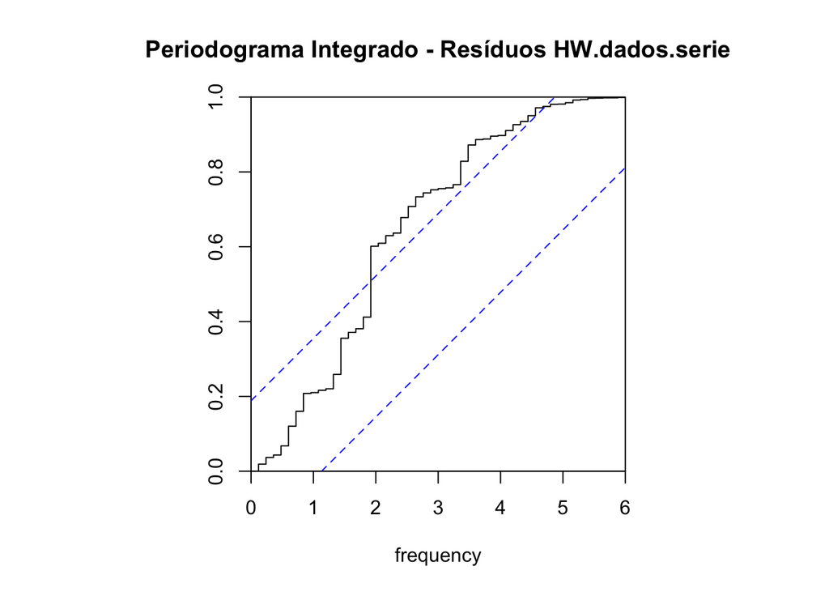

```r
cpgram(HW.dados.serie$residuals, main="Periodograma Integrado - Resíduos HW.dados.serie")
```

1. Quais os valores estimados para os parâmetros?
2. Comente sobre as características perceptíveis no gráfico do periodograma integrado para os resíduos do modelo.
7. Compare os modelos ajustados (ARIMA e Holt-Winters). Utilizando o Critério de Informação de Akaike (AIC), indique o melhor modelo.